# c9w1l2 rCharts

Robert Handsfield

11/23/2015

# rCharts

rCharts is a package that uses javascript to create interactive visualizations for R. It (kind of) emulates the javascript D3 library.

For more info, see

- http://ramnathv.github.io/rCharts/
- https://github.com/ramnathv/rCharts

Install rCharts with the following:

```r
require(devtools)
install_github(repo = 'rCharts', username = 'ramnathv')
```

Much of the interactivity is baked in by default via the various d3js libraries called by rCharts.

*Note: rChart plots render differently in knitr vs console. See StackOverflow.

For knitr:

- plot with `myPlot$print(title = 'title', include_assets=TRUE)`
- r chunk options must include `results='asis'`
- print the raw html with option `results='markup'`

For console:

- plot by calling the variable: `myPlot;`
- or by calling the plotting function: `rPlot(...);`

For RPubs:

- Use knitr with listed options
- use `myPlot$print(title = 'title', include_assets=TRUE, cdn=TRUE)`
  - `cdn=TRUE` instructs document to server JS+CSS from RPubs rather than your local directory asset library

### Example 1: MorrisJS Plotting Library

In this example, `reshape2::transform()` is loaded automatically by `rCharts`.

```r
require(rCharts)

data(economics, package = "ggplot2")
econ <- transform(economics, date = as.character(date))
m1 <- mPlot(x = "date", y = c("psavert", "uempmed"), type = "Line", data = econ)
m1$set(pointSize = 0, lineWidth = 1)
m1$print("chart2", include_assets=TRUE)
```

[output not shown]

Per http://ramnathv.github.io/rCharts/, rCharts has the following default libraries, invoked by the corresponding rChart functions.  
*Note: It appears that only Polychart and MorrisJS work out-of-the-box with rChart. The remainder need some additional libraries or configuration.

- Polychart: `rPlot()`
  - *Grammer of Graphics* syntax style, similar to **ggPlot2**
  - https://github.com/Polychart/polychart2

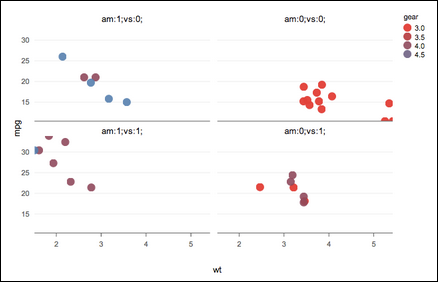

- MorrisJS: `mPlot()`
  - time series graphs: line, bar, area, donut style
  - http://morrisjs.github.io/morris.js/
  - https://github.com/oesmith/morris.js

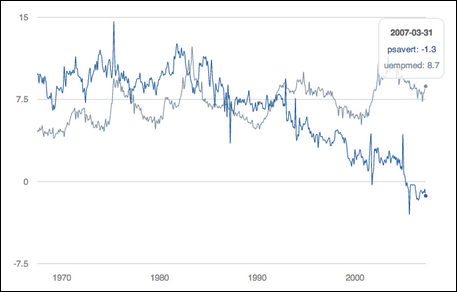

- NVD3: `nPlot()`
  - charts that require little customization, based reusable chart components
  - http://nvd3.org/
  - https://github.com/novus/nvd3
  - http://bost.ocks.org/mike/chart/

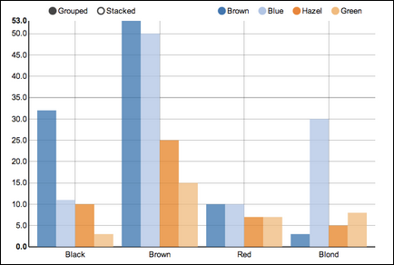

- xCharts: `xPlot()`
  - includes SVG for infinitely scalable charts
  - http://tenxer.github.io/xcharts/
  - https://github.com/tenXer/xcharts/

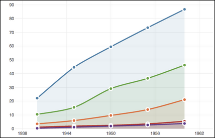

- HighCharts: `hPlot()`
  - claims to be simples & most flexible, free for non-commercial
  - related to js libraries *HighStock* (time series), *HighMaps* (maps), HighChartsCloud (cloud deployed charts)
  - http://www.highcharts.com/
  - Features: http://www.highcharts.com/products/highcharts/#open

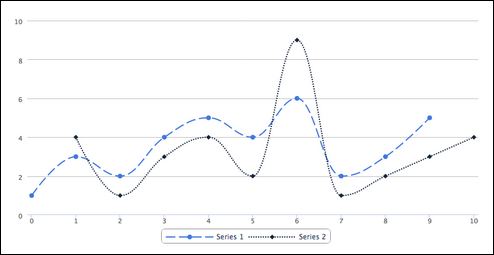

- Leaflet: `Leaflet$new()`
  - interactive maps
  - http://leafletjs.com/
  - Features: http://leafletjs.com/#features
  - 36 Plugins: http://leafletjs.com/plugins.html

[figure not shown]

- Rickshaw: `Rickshaw$new()`
  - time series charts
  - https://github.com/shutterstock/rickshaw

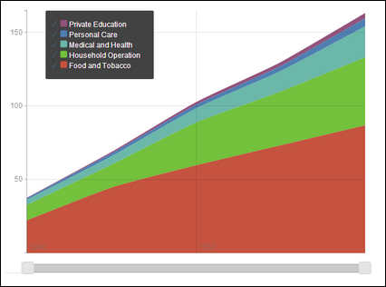

# Publishing rCharts

All static publishing is done with the `rCharts::_Plot::publish()` function.

Dynamic charts are embedded into Shiny by calling  
`rCharts::renderChart(expr = <all code>)` in `server.r`  
and  
`rCharts::showOutput(outputId='<name of chart var server::output$_____>', lib='js_plotting_lib')` in the `mainPanel()` function of `ui.r`.

```r
r1 <- rPlot(...)
r1$publish(title = 'Title', host = {'rpubs', 'gist', etc.})
```

## RPubs

```r
require(rCharts)

names(iris) = gsub("\\.", "", names(iris))

r1 <- rPlot(SepalLength ~ SepalWidth | Species, data = iris, color = 'Species', type = 'point')

r1$publish('Scatterplot', host = 'rpubs')
```

## Gist

```r
require(rCharts)

names(iris) = gsub("\\.", "", names(iris))

r1 <- rPlot(SepalLength ~ SepalWidth | Species, data = iris, color = 'Species', type = 'point')

r1$publish('Scatterplot', host = 'gist')
```